# PFNET_PyParserRAW

### Parser PSSE->PFNET

la idea es convertir archivos .RAW del psse y pasarlos a un objeto del tipo *network*

```python
#Se importa PFNET
import pfnet
```

Del modulo de PFNET se saca el parser de archivos .RAW, Que es un objeto.

```python
parser_psse=pfnet.PyParserRAW()
```

### Datos que convierte pfnet.PyParserRAW()

Por el momento solo se trabajo en la lectura de:

- Barras
- Generadores
- Cargas
- Shunts Fijos
- Shunts Variables (Resta resolver algunas cuestiones)
- Transformadores de 2 arrollamientos (Resta verificar su funcionamiento

### Como crear un objeto *network* en PFNET teniendo un caso en PSSE:

Teniendo el filename del caso, se lo pasa a traves de la funcion parse del parser.

```python
#Se utilizo el sistema de cuatro barras del libro "Analisis de sistemas de potencia"-Stevenson-Grainger

filename='C:\\Users\\Barberia Juan Luis\\Desktop\\case_4_gs.raw'
net=parser_psse.parse(filename)
```

```
case data: 0    100.00  33  0  1  60.00
record 1: CASE_4GS
record 2: TEST_PARSER_PSSE->PFNET
parsed 4 buses
parsed 4 loads
parsed 0 fixed shunts
parsed 2 generators
parsed 4 branches
parsed 0 transformers
parsed 0 areas
parsed 0 zones
parsed 0 owners
parsed 0 switched shunts
un-parsed lines:
  Q
```

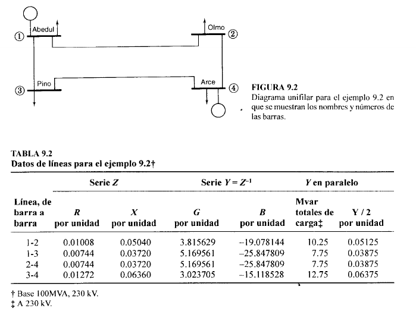

```python
from IPython.display import Image
Image(filename="C:\\Users\\Barberia Juan Luis\\Desktop\\case_4gs.png")
```

#### Obtencion de datos y componentes

- Para visualizar los datos se utiliza la forma DATOS = [network] . [lista_de_objetos][index] . [atributo]

```python
#ejemplo para ver la generacion de cada barra

GenA=[net.generators[0].P,net.generators[0].bus.name]
GenB=[net.generators[1].P,net.generators[1].bus.name]

print "Generador",GenA[1],"........   ",int(GenA[0]*net.base_power),"MW"
print "Generador",GenB[1],"........   ",int(GenB[0]*net.base_power),"MW"
```

```
Generador Arce         ........    318 MW
Generador Abedul       ........    192 MW
```

```python
#ejemplo para ver parametros serie de una linea

G=[branch.g for branch in net.branches]
B=[branch.b for branch in net.branches]

line=[str(branch.bus_k.name)+str(branch.bus_m.name) for branch in net.branches]

print line
print G
print B
```

```
['Pino        Arce        ', 'Olmo        Arce        ', 'Abedul      Pino        ', 'Abedul      Olmo        ']
[3.0237058538945325, 5.169561621174525, 5.169561621174525, 3.815628815628816]
[-15.118529269472663, -25.847808105872623, -25.847808105872623, -19.078144078144078]
```

- Para una rapida visualizacion de los componentes se puede utilizar el metodo show_components()

```python
net.show_components(output_level=1)
#Se puede modificar el output_level entre 1 y 2
```

```
Network Components
------------------
buses            : 4
shunts           : 0
branches         : 4
generators       : 2
loads            : 4
vargens          : 0
batteries        : 0
facts            : 0
csc converters   : 0
vsc converters   : 0
dc buses         : 0
dc branches      : 0
```

### Flujo de Potencia:

En esta seccion se muestra como llevar a cabo la formulacion de un flujo de potencia.

```python
from numpy import hstack
from numpy.linalg import norm
from scipy.sparse import bmat
from scipy.sparse.linalg import spsolve
```

##### Formulacion del flujo de potencia

ver seccion 4.4 de: https://pfnet-python.readthedocs.io/en/latest/problems.html

```python
def NRsolve(net):

    net.clear_flags()

    # bus voltage angles
    net.set_flags('bus',
                  'variable',
                  'not slack',
                  'voltage angle')

    # bus voltage magnitudes
    net.set_flags('bus',
                  'variable',
                  'not regulated by generator',
                  'voltage magnitude')

    # slack gens active powers
    net.set_flags('generator',
                  'variable',
                  'slack',
                  'active power')

    # regulator gens reactive powers
    net.set_flags('generator',
                  'variable',
                  'regulator',
                  'reactive power')

    p = pfnet.Problem(net)
    p.add_constraint(pfnet.Constraint('AC power balance', net))
    p.add_constraint(pfnet.Constraint('generator active power participation', net))
    p.add_constraint(pfnet.Constraint('PVPQ switching', net))
    p.add_heuristic(pfnet.Heuristic('PVPQ switching', net))
    p.analyze()

    x = p.get_init_point()
    p.eval(x)

    residual = lambda x: hstack((p.A*x-p.b, p.f))

    while norm(residual(x)) > 1e-4:
        p.apply_heuristics(x)
        x = x + spsolve(bmat([[p.A],[p.J]],format='csr'), -residual(x))
        p.eval(x)

    net.set_var_values(x)
    net.update_properties()
```

- Se corre dicho flujo de potencia en el caso cargado:

```python
NRsolve(net)
```

- Se muestran algunos resultados:

```python
import pandas as pd

df_v_mag=pd.DataFrame([bus.v_mag for bus in net.buses])
df_v_ang=pd.DataFrame([bus.v_ang*180/3.14 for bus in net.buses])

df_p_gen=pd.DataFrame([bus.get_total_gen_P()*net.base_power for bus in net.buses])
df_q_gen=pd.DataFrame([bus.get_total_gen_Q()*net.base_power for bus in net.buses])

df_p_load=pd.DataFrame([bus.get_total_load_P()*net.base_power for bus in net.buses])
df_q_load=pd.DataFrame([bus.get_total_load_Q()*net.base_power for bus in net.buses])

df=pd.concat([df_v_mag, df_v_ang ,df_p_gen ,df_q_gen,df_p_load ,df_q_load], axis=1)
df.columns=['v_mag_pu','v_ang_deg','p_gen_MW','q_gen_MVAR','p_load_MW','q_load_MW']
df.index=[str(bus.name) for bus in net.buses]

df
```

|  | v_mag_pu | v_ang_deg | p_gen_MW | q_gen_MVAR | p_load_MW | q_load_MW |
| --- | --- | --- | --- | --- | --- | --- |
| Arce | 1.020000 | 1.524549 | 318.000000 | 201.213493 | 80.0 | 49.58 |
| Pino | 0.966590 | -1.852339 | 0.000000 | 0.000000 | 200.0 | 123.94 |
| Olmo | 0.980479 | -0.958382 | 0.000000 | 0.000000 | 170.0 | 105.35 |
| Abedul | 1.000000 | 0.000000 | 187.022562 | 133.759319 | 50.0 | 30.99 |

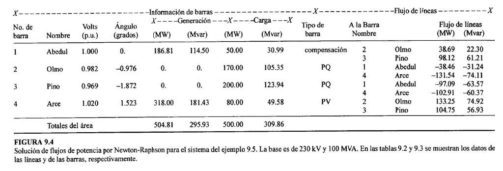

```python
Image(filename="C:\\Users\\Barberia Juan Luis\\Desktop\\solution_case4gs.png")
```

#### Conclusion:

Faltaria testear con un caso mas complejo.

# DUDAS:

- Donde esta el caso IEEE_25_RAW ya que al correr el test omite los .RAW

https://github.com/ttinoco/PFNET.py/blob/master/tests/test_parser.py#L143

- Este es el modelo de transformador de 2 arrollamientos en PSSE?:

https://w3.usa.siemens.com/datapool/us/SmartGrid/docs/pti/2009July/PDFs/Modeling_of_two_winding_voltage_regulating_transformers.pdf

- Los costos de los generadores en que parte del PSSE estan, Tambien deberiamos pasarlos